# Prediciting activity class based on fitness tracker data

Peter Cooman

Monday, August 10, 2015

Fitness trackers like the Nike Fuelband and the Fitbit provide us with a wealth of information. Research participants were asked to perforam barbell lifts both correctly and incorrectly in five different ways. The goal of this project is to train a model that allows us to classify the various observations among these five classes based on acceleration measurements.

We begin by reading in the training and testing data sets:

```r
training <- read.csv("pml-training.csv", header = TRUE, na.strings = "NA", stringsAsFactors = FALSE)
testing <- read.csv("pml-testing.csv", header = TRUE, na.strings = "NA", stringsAsFactors = FALSE)
```

Next, we take a quick look at the data and its structure:

```r
head(training)
head(testing)

summary(training)
summary(testing)

# Output suppressed for the sake of brevity
```

These summaries show us that the there are 160 featues. However, many columns contain a large number of missing values. In fact we find that for 100 columns in the testing set all data is missing. Since these features are effectively unavailable when making predictions, we will discard them in both the training and testing data sets:

```r
testing <- testing[ ,!apply(testing,2, function(x) all(is.na(x))) ]

# split off labels first so we don't lose them
labels <- training$classe

# only retain features that are also present in the testing set
training <- training[,names(training) %in% names(testing)]
```

As for the predicitve model, I have chosen a Random Forest. This approach ahs many advantages: it is applicable to classification problem, is often highly accurate and is easy to tune. Random Forests do have some drawbacks. They can take a long time to train if there is a lot of data and they are difficult to interpret. However, the data set is relatively small (19622 observations) and interpreatability is not a significant concern for this assignment, so these issues should not be a concern.

First, we convert classe (A through E) to the numbers 1 through 5 respectively.

```r
labels <- as.factor(labels)
labels <- as.factor(match(labels, levels(labels)))  # convert to numeric
```

Next, we convert the user_name categories to numerical values:

```r
# define as factors first
training$user_name <- as.factor(training$user_name)
testing$user_name <- as.factor(testing$user_name)

# then convert to numericals, making sure that both training and testing sets use the same replacement table
# 1: Adelmo, 2: Carlitos, 3: Charles, 4: Eurico, 5: Jeremy, 6: Pedro
testing$user_name <- match(testing$user_name, levels(training$user_name))
training$user_name <- match(training$user_name, levels(training$user_name))
```

```r
library(lubridate)
# For the training data set
training$day <- mday(dmy_hm(training$cvtd_timestamp))
training$month <- month(dmy_hm(training$cvtd_timestamp))
#training$year <- year(dmy_hm(training$cvtd_timestamp))
training$hour <- hour(dmy_hm(training$cvtd_timestamp))
training$minute <- hour(dmy_hm(training$cvtd_timestamp))
training$cvtd_timestamp <- NULL

# Need to repeat this for the testing data set
testing$day <- mday(dmy_hm(testing$cvtd_timestamp))
testing$month <- month(dmy_hm(testing$cvtd_timestamp))
#testing$year <- year(dmy_hm(testing$cvtd_timestamp))
testing$hour <- hour(dmy_hm(testing$cvtd_timestamp))
testing$minute <- hour(dmy_hm(testing$cvtd_timestamp))
testing$cvtd_timestamp <- NULL
```

Note that the year feature has been omitted, given that all data was collected in 2011.

Next, we replace the new_window feature in both data sets with either 0 for “no” or 1 for “yes”:

```r
training$new_window <- ifelse(training$new_window == "no",0,1)
testing$new_window <- ifelse(testing$new_window == "no",0,1)
```

Finally, I removed the index numbers.

```r
# Remove problem_id from test set
testing$problem_id <- NULL

# remove indeces
training$X <- NULL
testing$X <- NULL
```

Our data is now ready for training the model. We have sufficient observations to do a classic data partitioning. Here, I chose to use 75% of the training data to train the data. I set aside the remaining 25% for cross validation.

```r
library(caret)
set.seed(666)

inTrain = createDataPartition(labels, p = 0.75)[[1]]

CVtraining_feats <- training[inTrain,]
CVtraining_labels <- labels[inTrain]
CVtesting_feats <- training[-inTrain,]
CVtesting_labels <- labels[-inTrain]
```

Next, we train a Random Forest model on the cross validation training set.

```r
library(randomForest)
RF_model <- randomForest(x = CVtraining_feats, y = CVtraining_labels, ntree = 100, importance = TRUE)
```

A quick plot of the training error shows that 100 trees is more than enough. The classification error plateaud much earlier.

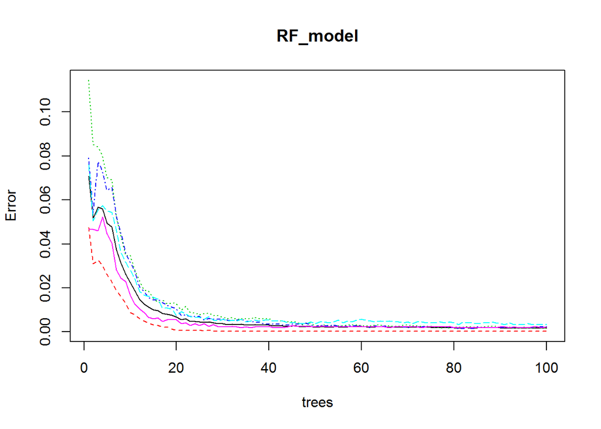

```r
windows()
plot(RF_model)
```

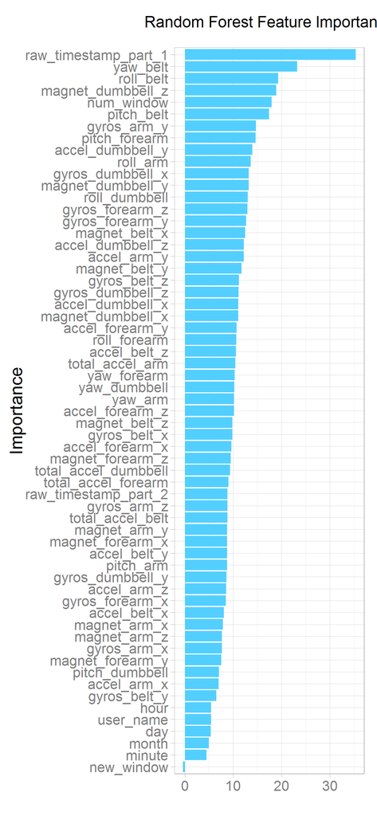

```r
imp <- importance(RF_model, type=1)
featureImportance <- data.frame(Feature=row.names(imp), Importance=imp[,1])

windows()
p <- ggplot(featureImportance, aes(x=reorder(Feature, Importance), y=Importance)) +
  geom_bar(stat="identity", fill="#53cfff") +
  coord_flip() +
  theme_light(base_size=20) +
  xlab("Importance") +
  ylab("") +
  ggtitle("Random Forest Feature Importance\n") +
  theme(plot.title=element_text(size=18))
print(p)
```

To get an estimate of the accuracy of our model, we compute the model predictions for the cross validation training set (which we used to train the model). We find that the model achieves perfect accuracy: 100% correct classification.

```r
RF_preds_train <- predict(RF_model, newdata = CVtraining_feats)
confusionMatrix(RF_preds_train,CVtraining_labels)
```

```
## Confusion Matrix and Statistics
##
##           Reference
## Prediction    1    2    3    4    5
##          1 4185    0    0    0    0
##          2    0 2848    0    0    0
##          3    0    0 2567    0    0
##          4    0    0    0 2412    0
##          5    0    0    0    0 2706
##
## Overall Statistics
##
##                Accuracy : 1
##                  95% CI : (0.9997, 1)
##     No Information Rate : 0.2843
##     P-Value [Acc > NIR] : < 2.2e-16
##
##                   Kappa : 1
##  Mcnemar's Test P-Value : NA
##
## Statistics by Class:
##
##                      Class: 1 Class: 2 Class: 3 Class: 4 Class: 5
## Sensitivity            1.0000   1.0000   1.0000   1.0000   1.0000
## Specificity            1.0000   1.0000   1.0000   1.0000   1.0000
## Pos Pred Value         1.0000   1.0000   1.0000   1.0000   1.0000
## Neg Pred Value         1.0000   1.0000   1.0000   1.0000   1.0000
## Prevalence             0.2843   0.1935   0.1744   0.1639   0.1839
## Detection Rate         0.2843   0.1935   0.1744   0.1639   0.1839
## Detection Prevalence   0.2843   0.1935   0.1744   0.1639   0.1839
## Balanced Accuracy      1.0000   1.0000   1.0000   1.0000   1.0000
```

Our model fits the training dtaa perfectly, but we may be overfitting. To get a better idea of the true classifcation accurcy, we need to predict the labels for the cross validation testing set.

```r
RF_preds_test <- predict(RF_model, newdata = CVtesting_feats)
confusionMatrix(RF_preds_test,CVtesting_labels)
```

```
## Confusion Matrix and Statistics
##
##           Reference
## Prediction    1    2    3    4    5
##          1 1395    0    0    0    0
##          2    0  949    1    0    0
##          3    0    0  854    2    0
##          4    0    0    0  802    0
##          5    0    0    0    0  901
##
## Overall Statistics
##
##                Accuracy : 0.9994
##                  95% CI : (0.9982, 0.9999)
##     No Information Rate : 0.2845
##     P-Value [Acc > NIR] : < 2.2e-16
##
##                   Kappa : 0.9992
##  Mcnemar's Test P-Value : NA
##
## Statistics by Class:
##
##                      Class: 1 Class: 2 Class: 3 Class: 4 Class: 5
## Sensitivity            1.0000   1.0000   0.9988   0.9975   1.0000
## Specificity            1.0000   0.9997   0.9995   1.0000   1.0000
## Pos Pred Value         1.0000   0.9989   0.9977   1.0000   1.0000
## Neg Pred Value         1.0000   1.0000   0.9998   0.9995   1.0000
## Prevalence             0.2845   0.1935   0.1743   0.1639   0.1837
## Detection Rate         0.2845   0.1935   0.1741   0.1635   0.1837
## Detection Prevalence   0.2845   0.1937   0.1746   0.1635   0.1837
## Balanced Accuracy      1.0000   0.9999   0.9992   0.9988   1.0000
```

We find that the Random Forest model achieves an out of sample accuracy of 99.94%. This should be accurate enough!

The only thing left to do is to make our predictions for the original testing data set (20 observations) and to save the results in the correct file formats.

```r
# Predictions for evaluation set
RF_preds_eval <- predict(RF_model,newdata = testing)
RF_preds_eval
```

```
##  1  2  3  4  5  6  7  8  9 10 11 12 13 14 15 16 17 18 19 20
##  2  1  2  1  1  5  4  2  1  1  2  3  2  1  5  5  1  2  2  2
## Levels: 1 2 3 4 5
```

```r
answers = c("B","A","B","A","A","E","D","B","A","A","B","C","B","A","E","E","A","B","B","B")

pml_write_files = function(x){
  n = length(x)
  for(i in 1:n){
    filename = paste0("problem_id_",i,".txt")
    write.table(x[i],file=filename,quote=FALSE,row.names=FALSE,col.names=FALSE)
  }
}

pml_write_files(answers)
```